# Short Oktoberfest Analysis

Thomas Schmidt

2018-04-11

# Set up environment

```r
require(httr, quietly = T)
require(jsonlite, quietly = T)
require(tidyverse, quietly = T, warn.conflicts = F)
require(gridExtra, quietly = T, warn.conflicts = F)
require(grid, quietly = T, warn.conflicts = F)
```

# Importing data from API

```r
url <- "https://www.opengov-muenchen.de"
path <- "api/action/datastore_search?resource_id=e0f664cf-6dd9-4743-bd2b-81a8b18bd1d2"
# get raw results
raw.result <- GET(url = url, path = path)
# convert raw results to list
result <- content(raw.result)
# convert results to table
dt <- bind_rows(result$result$records)
```

# Prepare data

Let’s take a quick view at our data:

```r
head(dt)
```

| hendl_preis | jahr | besucher_gesamt | hendl_konsum | dauer | bier_konsum | bier_preis | _id | besucher_tag |
| --- | --- | --- | --- | --- | --- | --- | --- | --- |
| 4.77 | 1985 | 7.1 | 629520 | 16 | 54541 | 3.20 | 1 | 444 |
| 3.92 | 1986 | 6.7 | 698137 | 16 | 53807 | 3.30 | 2 | 419 |
| 3.98 | 1987 | 6.5 | 732859 | 16 | 51842 | 3.37 | 3 | 406 |
| 4.19 | 1988 | 5.7 | 720139 | 16 | 50951 | 3.45 | 4 | 356 |
| 4.22 | 1989 | 6.2 | 775674 | 16 | 51241 | 3.60 | 5 | 388 |
| 4.47 | 1990 | 6.7 | 750947 | 16 | 54300 | 3.77 | 6 | 419 |

As we see, the columns have german names. We will change this for all english speaking readers.

```r
dt <- dt %>%
  transmute(id = `_id`,
            year = as.integer(jahr),
            duration = as.integer(dauer),
            beer_cons = as.integer(bier_konsum)*100, # change metric to L
            hendl_cons = as.integer(hendl_konsum)/2, # change metric from 1/2 to 1 chicken
            beer_price = as.numeric(bier_preis),
            beer_price_dm = beer_price * 1.95583,
            hendl_price = as.numeric(hendl_preis),
            hendl_price_dm = hendl_price * 1.95583,
            visitors_total = as.numeric(besucher_gesamt) * 1000000, # change metric to nr. of people
            visitors_day = as.integer(besucher_tag)*1000) # change metric to nr. of people
dt.copy <- dt
```

# Data description

| Variable | Metric |
| --- | --- |
| beer consumption | L |
| beer price | €/Liter |
| hendl consumption | Chicken |
| hendl price | € |
| total visitors | People |
| daily visitors | People |

# Data munging

No we will start to work with the oktoberfest data set. We will add some information like the years when the Bavarian Central Agricultural Festival (ZLF) took place.

```r
# generate vector with years in which zlf festival took place
zlf_years <- c(seq(1810,1996, 3), seq(2000, max(dt$year),4))
dt <- dt.copy %>%
  mutate(zlf = factor(ifelse(year %in% zlf_years, 1, 0)),
         currency = factor(ifelse(year < 2002, "DM", "€")),
         beer_price_change = beer_price/lag(beer_price, 1) - 1) %>%
  select(-id) # remove is column
dt$beer_price_change[1] <- 0 # change first value to 0 since NA
```

# Data analysis

## Beer price and consumption

One of the most things some people are complaining about the Oktoberfest is the its beer price. So our first question on the data set is:

**How did the beer price develope from 1985 to 2016?**

*Note: The currency used in the data is €. All prices before the year 2002 seem to be transformed from DM (german currency before 2002) to Euro.*

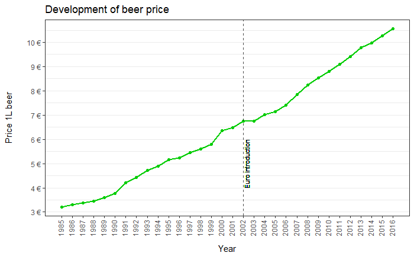

In fact the prie for 1L beer increased almost linear over the years. We will try to use a simple model to descripe the data:

```r
fit <- lm(beer_price ~ year, data = dt)
fit_dm <- lm(beer_price ~ year, data = subset(dt, year < 2002))
fit_euro <- lm(beer_price ~ year, data = subset(dt, year >= 2002))
```

If we fit a linear regression model to the data, the simple model suggests that the beer price increased by **0.24 Cents per year**.

Fitting models to the years with different curencies separately, we see a small differens in estimated price increase per year:  
In years with DM currency the estimated yearly price increase was about **0.21 Cents per year**. In the years after the Euro has been introduced, the estimated yearly price increase was **0.29 Cents per year**.

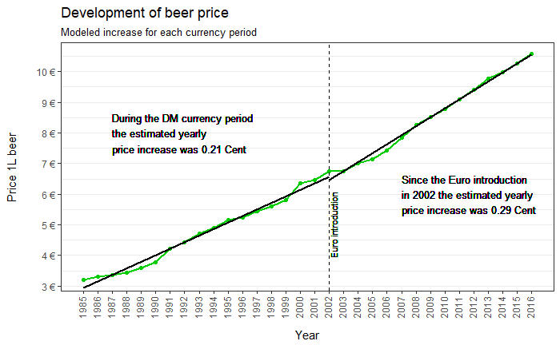

Now that we know that the price increased over the years, the next question which arises is:

**Did this increase have a negative influence on mean beer consumption per visitor?**

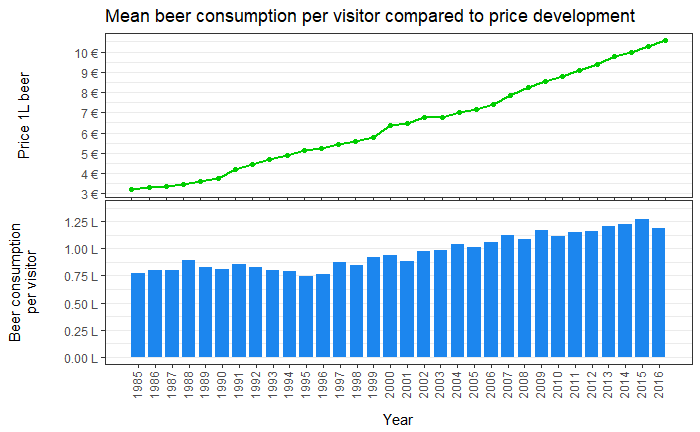

We do not see a decline in mean beer consumption per visitor over the years. In fact, since around year 1999 it seems that it even has been increasing steadily.

So the data set suggests that the price does **not** seem to have a negative influence on mean beer consumption per visitor.

## Hendl price and consumption

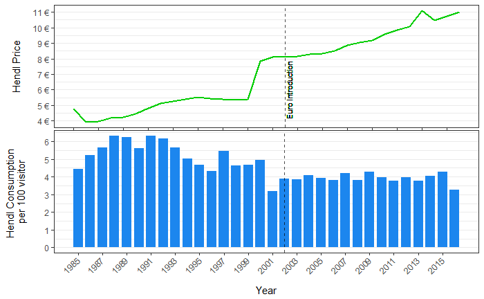

```r
p1 <- dt %>%
  ggplot() +
  geom_line(aes(x = year, y = hendl_price), color = fillCol3, size = 1) +
  #geom_col(aes(x = year, y = hendl_price), fill = fillCol3, width = 0.8) +
  geom_vline(xintercept = 2002, lty = 2, alpha = 0.7, size = 0.7) +
  geom_text(x = 2002, y = 10, label = "Euro Introduction", angle = 90, vjust = 1.1, cex = 3,
            hjust = 1.6) +
  scale_y_continuous(labels = scales::dollar_format(suffix = " €", prefix = ""),
                     breaks = seq(0, max(dt$hendl_price), 1)) +
  scale_x_continuous(breaks = seq(min(dt$year), max(dt$year), 2)) +
  xlab("Year") +
  ylab("Hendl Price") +
  my_theme +
  theme(axis.text.x = element_blank(),
        axis.title.x = element_blank(),
        plot.margin = unit(c(5.5,5.5,0,5.5), "points"))
p2 <- dt %>%
  ggplot() +
  geom_col(aes(x = year, y = hendl_cons/visitors_total*100), fill = fillCol1, width = 0.8) +
  geom_vline(xintercept = 2002, lty = 2, alpha = 0.7, size = 0.7) +
  scale_y_continuous(breaks = seq(0, max(dt$hendl_cons/dt$visitors_total*100), 1)) +
  scale_x_continuous(breaks = seq(min(dt$year), max(dt$year), 2)) +
  xlab("Year") +
  ylab("Hendl Consumption \nper 100 visitor") +
  my_theme +
  theme(axis.text.x = element_text(angle = 45, vjust = 1.5, hjust = 1.4),
        plot.margin = unit(c(0,5.5,5.5,5.5), "points"))
grid.newpage()
grid.draw(rbind(ggplotGrob(p1), ggplotGrob(p2), size = "last"))
```

## Bavarian Central Agricultural Festival (ZLF)

### Did the ZLF bring more visitor to the Oktoberfest (remove outlier 2001)

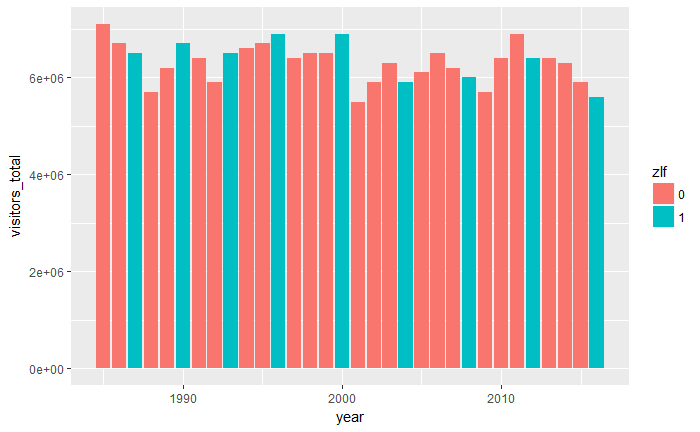

```r
dt %>%
  ggplot() +
  geom_col(aes(x = year, y = visitors_total, fill = zlf))
```

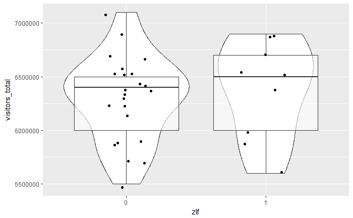

```r
dt %>%
  ggplot(aes(x = zlf, y = visitors_total)) +
  geom_violin(aes(x = zlf, y = visitors_total)) +
  geom_boxplot( alpha = 0.6) +
  geom_jitter(position = position_jitter(height = NULL, width = 0.2))
```

### Did the visitors consume more beer in ZLF years

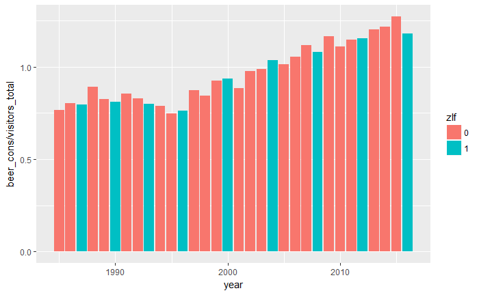

```r
dt %>%
  ggplot() +
  geom_col(aes(x = year, y = beer_cons/visitors_total, fill = zlf))
```

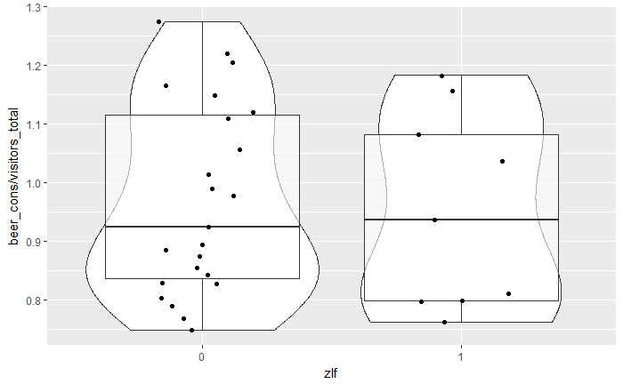

```r
dt %>%
  ggplot(aes(x = zlf, y = beer_cons/visitors_total)) +
  geom_violin() +
  geom_boxplot( alpha = 0.6) +
  geom_jitter(position = position_jitter(height = NULL, width = 0.2))
```

### Did the visitors consume more hendl in ZLF years

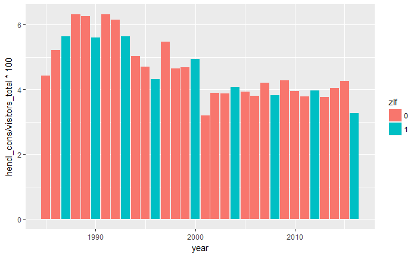

```r
dt %>%
  ggplot() +
  geom_col(aes(x = year, y = hendl_cons/visitors_total*100, fill = zlf))
```

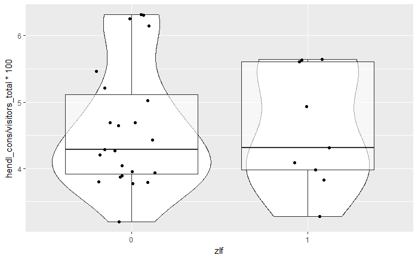

```r
dt %>%
  ggplot(aes(x = zlf, y = hendl_cons/visitors_total*100)) +
  geom_violin() +
  geom_boxplot( alpha = 0.6) +
  geom_jitter(position = position_jitter(height = NULL, width = 0.2))
```

# Quick plots

## Beer consumption vs. zlf

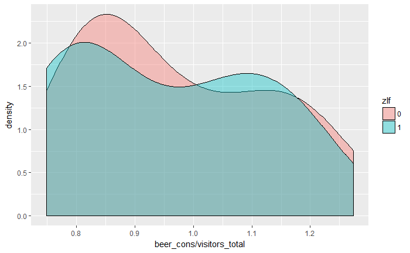

```r
dt %>%
  ggplot() +
  geom_density(aes(x = beer_cons/visitors_total, fill = zlf), alpha = 0.4)
```

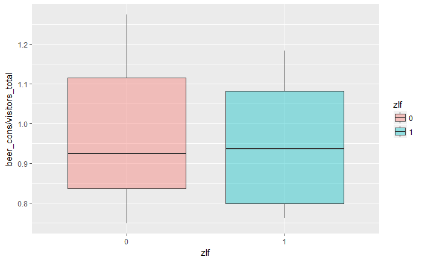

```r
dt %>%
  ggplot() +
  geom_boxplot(aes(x = zlf, y = beer_cons/visitors_total, fill = zlf), alpha = 0.4)
```

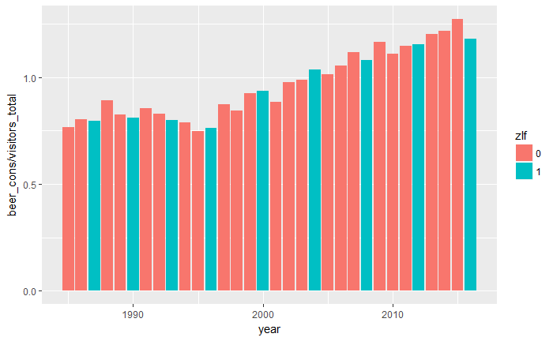

```r
dt %>%
  ggplot() +
  geom_col(aes(x =  year, y = beer_cons/visitors_total, fill = zlf))
```

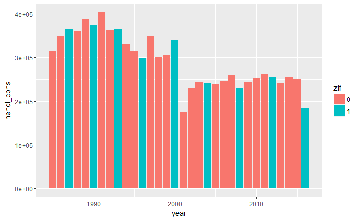

## beer price increase before and after euro

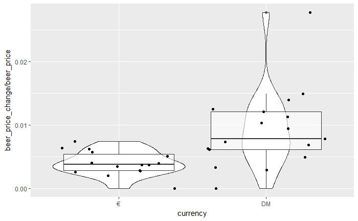

# Ideas

- Zusätzlicher Datensatz mit Zeltpreisen suchen
- Zusätzlicher Datensatz mit Wetter -> % der Tage mit Regen